# RMarkdown

H24076150

2020/5/4

## RMarkdown

- Compile a single R Markdown document to a report in different formats, such as PDF, HTML, or Word.
- Creat notebooks in which you can directly run code chunks interactivity.
- Make slides for presentations(HTML5, LaTex Beamer, or PowerPoint).

Sources:

https://bookdown.org/yihui/rmarkdown/

https://rmarkdown.rstudio.com/articles_intro.html

https://rmarkdown.rstudio.com/lesson-1.html

https://rstudio.com/wp-content/uploads/2015/02/rmarkdown-cheatsheet.pdf

## Install package “RMarkdown”

```r
install.packages("rmarkdown")
```

- Start from creating a new file .Rmd
1. In the menu bar, click **File** -> **New File** -> **R Markdown**…
2. A window will open. Select the class of output you would like to make with your .Rmd file
3. Select the specific type of output to make with radio buttons (you can change this later)
4. Click OK

## Some basic editings

In the .Rmd file,

```r
*italics* and _italics_
**bold** and __bold__
superscript^2^
--strikethrough--
```

*italics* and *italics*

**bold** and **bold**

superscript<sup>2</sup>

–strikethrough–

## Headers of a Paragraph

Use “#” to show the paragraph.

```r
# Header 1
## Header 2
### Header 3
#### Header 4
##### Header 5
###### Header 6
```

In slides:

Header 1 will be shown in the table of content.

Header 2 will be the title of the slide.

## Equations

```r
$A = \pi*r^{2}$
$$B = 2 \pi r$$
```

Inline equation: $A = \pi*r^{2}$

Center an equation:
$$B = 2 \pi r$$

## Bullet point

```r
* unordered list
* item2
    + sub-item 1

1. ordered list
2. item 2
    + sub-item 1
```

- unordered list
- item2
  - sub-item 1
1. ordered list
2. item 2
   - sub-item 1

## Table (I)

```r
Table Header | Second Header
------------ | -------------
Table Cell   | Cell 2
Cell 3       | Cell 4
```

| Table Header | Second Header |
| --- | --- |
| Table Cell | Cell 2 |
| Cell 3 | Cell 4 |

## Table (II)

```r
\begin{table}[h]
  \centering
  \begin{tabular}{c|cc}
    \hline
    $x_j$ & 0 & 1 \\
    \hline
    $p_j$ & 0.3 & 0.7 \\
    \hline
  \end{tabular}
  \caption{Random variable $X$ with its probability}
\end{table}
```

## Matrix

```r
$\left[
    \begin{array}{cc}
      A & B \\
      C & C \\
    \ebd{array}
 \right]$
```

$\left[ \begin{array}{cc} A & B \\ C & D \\ \end{array} \right]$

## Inline R codes

Two times three equals

```r
`r 2 * 3`
```

Two times three equals 6.

## R codes with graph

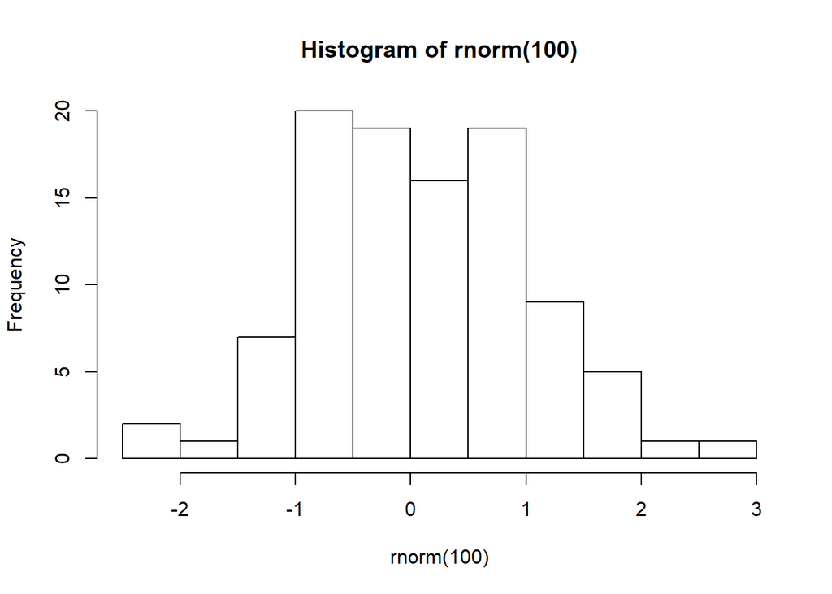

```r
y <- 2 * 3 - 1
hist(rnorm(100))
```

Use **fig.width** and **fig.height** to adjust the size of a graph.

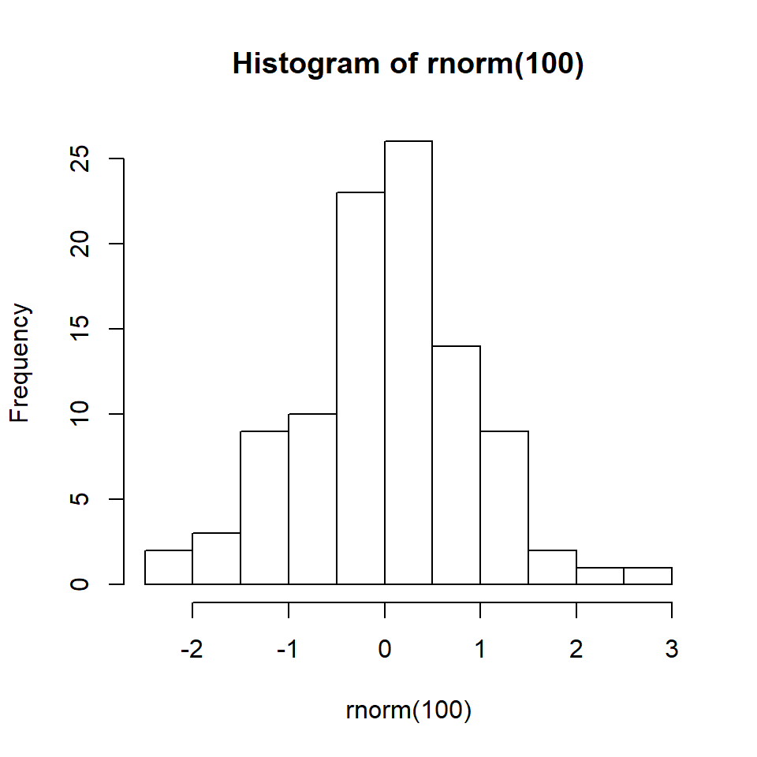

```r
hist(rnorm(100))
```

## Options

| Option | default | effect |
| --- | --- | --- |
| eval | TRUE | Whether to evaluate the code and include its results |
| echo | TRUE | Whether to display code along with its results |
| warning | TRUE | Whether to display warnings |
| error | FALSE | Whether to display errors |
| message | TRUE | Whether to display messages |
| tidy | FALSE | Whether to reformat code in a tidy way when displaying it |
| results | “markup” | “markup”, “asis”, “hold”, or “hide” |
| cache | FALSE | Whether to cache results for future renders |
| comment | “##” | Comment character to preface results with |
| fig.width | 7 | Width in inches for plots created in chunk |
| fig.height | 7 | Height in inches for plots created in chunk |

## Showing an existed figure

In the XXX.Rmd, type the following code:

```r
![caption](name.jpg){width=25%}
```

[figure not shown]

Taipei 101

## Plot the pmf

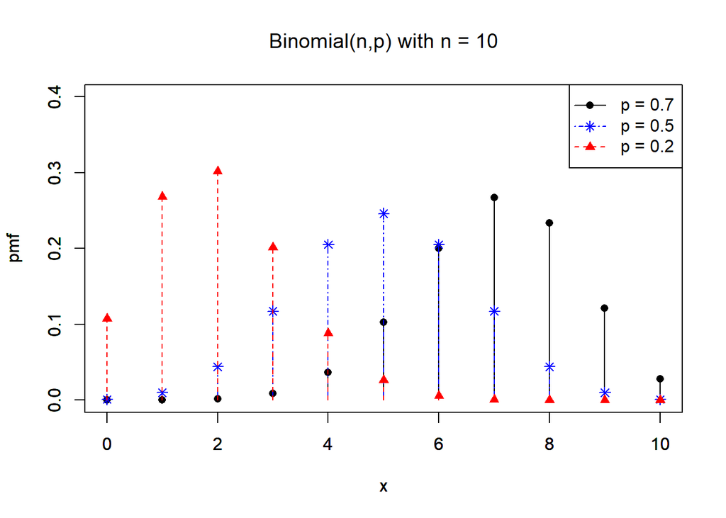

```r
bin <- c(0.7,0.5,0.2)
col_b <- c("black", "blue", "red")
lty_b <- c(1,4,2)
pch_b <- c(16,8,17)
for(i in 1:length(bin)){
  x <- 0:10
  pmf <- dbinom(x,10,bin[i])
  plot(x, pmf, type = c("h"), col = col_b[i], lty = lty_b[i], ylim = c(0.0, 0.4))
  points(x, pmf, pch = pch_b[i], col = col_b[i])
  if(i+1 <= length(bin)){
    par(new = TRUE)
  }
}
legend("topright", pch = pch_b, lty = lty_b, col = col_b, legend = c(expression(paste("p = 0.7")),expression(paste("p = 0.5")),expression(paste("p = 0.2"))))
title(expression(paste("Binomial(n,p) with n = 10")))
```

## Some settings for the slides

```r
title: "AAA"
author: "BBB"
date: "May 4, 2020"
output:
  beamer_presentation:
    slide_level: 2
    toc: yes
  ioslides_presentation: default
  slidy_presentation: default
theme: CambridgeUS
colortheme: beaver
```

https://bookdown.org/yihui/rmarkdown/beamer-presentation.html

https://hartwork.org/beamer-theme-matrix/